# Development and Validation of Prediction Model for Major Adverse Cardiac Events in Patients with Chronic Inflammatory Skin Diseases Undergoing Major Surgical

Reading in the data from MIMIC-IV (*accessible here: https://mimic.mit.edu/docs/iv/*), containing:

1. Patient-level data from 2008-2019 for hospitalized patients at the Beth Israel Deaconess Medical Center
2. Hospital admission-level data from the same period and hospital
3. Diagnoses assigned to the patients admitted from the same period and hospital

We will be accessed the MIMIC-IV Data set. The MIMIC-IV dataset consists of free and comprehensive clinical data on hospital stays for patients admitted to Beth Israel Deaconess Medical Center (BIDMC) in Boston, MA. In order to attain access to the data, all team members conducted CITI training in order to become credentialed users on PhysioNet, signed the data use agreement (DUA), and followed tutorials for direct cloud access and download the data locally from the aforementioned website.

```r
patients <- read_csv("patients.csv")
admissions <- read_csv("admissions.csv")
diagnoses_icd <- read_csv("diagnoses_icd.csv")
```

Using the following diagnosis codes (both ICD-9 and ICD-10), we define a variable for whether a code refers to one of our inclusion criteria: hidradenitis suppurativa: 70583, L73.2 psoriasis: 6960, 6961,6962, 696.8, L.40.x, L.40.5x atopic dermatitis: 6910, 6918, L20.x, L20.8x alopecia areata: 70400, 70401, L63.x vitiligo: 70901, L80

```r
dermlist <- c("70583","L732","6960","6961","6962","6968","L40.","L405","6910","6918","L20.","L208","70400","70401","L63.","70901","L80.","70583","L732","6960","6961","6962","6968","L40","L405","6910","6918","L20","L208","70400","70401","L63","70901","L80")
hidlist <- c("70583","L732")
psorlist <- c("6960","6961","6962","6968","L40.","L405","L40")
atoplist <- c("6910","6918","L20.","L208","L20")
aloplist <- c("70400","70401","L63")
vitlist <- c("70901","L80")
```

Next, we define variables for key clinical covariates (components of the Charlson Comorbidity Index), similarly using ICD-9 and ICD-10 codes. *(See Charlson M et al. Validation of a combined comorbidity index. J Clin Epi 1994)*

```r
milist<-c("I21.","I22.","I252.","410.","412.","I21","I22","I252","410","412")
chflist<-c("I099","I110","I130","I132","I255","I420","I425","I426","I427","I428","I429","I43.","I50.","P290","39891","40201","40211","40291","40401","40403","40411","40413","40491","40493","4254","4255","4256","4257","4258","4259","428")
hivlist<-c("042.","044.","B20.","B22.","B24.","042","044","B20","B22","B24")
pvdlist<-c("I70.","I71.","I731","I738","I739","I771","I790","I792","K551","K558","K559","Z958","Z959","0930","4373","440.","441.","443.","4471","5571","5579","V434","I70","I71","I731","I738","I739","I771","I790","I792","K551","K558","K559","Z958","Z959","0930","4373","440","441","443","4471","5571","5579","V434")
cvalist <- c("G45.","G46.","H340","I60.,","I61.","I62.","I63.","I64.","I65.","I66.","I67.","I68.","I69.","36234","430.","431.","432.","433.","434.","435.","436.","437.","438.","G45","G46","H340","I60,","I61","I62","I63","I64","I65","I66","I67","I68","I69","36234","430","431","432","433","434","435","436","437","438")
demlist <- c("F00.","F01.","F02.","F03.","F051","G30.","G311","290.","2941","3312","F00","F01","F02","F03","F051","G30","G311","290.","2941","3312")
copdlist <- c("I278","I279","J40.","J41.","J42.","J43.","J44.","J45.","J46.","J47.","J60.","J61.","J62.","J63.","J64.","J65.","J66.","J67.","J684","J701","J703","4168","4169","490.","491.","492.","493.","494.","495.","496.","497.","498.","499.","500.","501.","502.","503.","504.","505.","5064","5081","5088","I278","I279","J40","J41","J42","J43","J44","J45","J46","J47","J60","J61","J62","J63","J64","J65","J66","J67","J684","J701","J703","4168","4169","490","491","492","493","494","495","496","497","498","499","500","501","502","503","504","505","5064","5081","5088")
rheumlist <- c("M05.","M06.","M315","M32.","M33.","M34.","M351","M353","M360","4465","7100","7101","7102","7103","7104","7140","7141","7142","7148","725.","M05","M06","M315","M32","M33","M34","M351","M353","M360","4465","7100","7101","7102","7103","7104","7140","7141","7142","7148","725")
pudlist <- c("K25.","K26.","K27.","K28.","531.","532.","533.","534.","K25","K26","K27","K28","531","532","533","534")
mstlist <- c("C77.","C80.","196.","199.","C77","C80","196","199")
livmod <- c("I850","I859","1864","I982","K704","K711","K721","K729","K765","K766","K767")
maliglist <-c("4560","4562","5722","5728","C00.","C26.","C30.","C34.","C37.","C41.","C43.","C45.","C58.","C60.","C76.","C81.","C85.","C88.","C90.","C97.","4560","4562","5722","5728","C00","C26","C30","C34","C37","C41","C43","C45","C58","C60","C76","C81","C85","C88","C90","C97")
renallist <-c("40301","40311","40391","40402","40403","40412","40413","40492","40493","582.","5830","5831","5832","5833","5834","5835","5836","5837","585.","586.","5880","V420","V451","V56.","I120","I131","N032","N033","N034","N035","N036","N037","N052","N053","N054","N055","N056","N057","N18.","N19.","N250","Z490","Z491","Z492","Z940","Z992","40301","40311","40391","40402","40403","40412","40413","40492","40493","582","5830","5831","5832","5833","5834","5835","5836","5837","585","586","5880","V420","V451","V56","I120","I131","N032","N033","N034","N035","N036","N037","N052","N053","N054","N055","N056","N057","N18","N19","N250","Z490","Z491","Z492","Z940","Z992")
mildlivlist<-c("B18.","K700","K701","K702","K703","K709","K713","K714","K715","K717","K73.","K74.","K760","K762","K763","K764","K768","K769","Z944","07022","07023","07032","07033","07044","07054","0706","0709","570.","571.","5733","5734","5738","5739","V427","B18","K700","K701","K702","K703","K709","K713","K714","K715","K717","K73","K74","K760","K762","K763","K764","K768","K769","Z944","07022","07023","07032","07033","07044","07054","0706","0709","570","571","5733","5734","5738","5739","V427")
pleglist<-c("3341","342.","343.","3440","3441","3442","3443","3444","3445","3446","3449","G041","G114","G801","G802","G81x","G82.","G830","G831","G832","G833","G834","G839","3341","342","343","3440","3441","3442","3443","3444","3445","3446","3449","G041","G114","G801","G802","G81x","G82.","G830","G831","G832","G833","G834","G839")
dmcomplist<-c("2504","2505","2506","2507","E102","E103","E104","E105","E107","E112","E113","E114","E115","E117","E122","E123","E124","E125","E127","E132","E133","E134","E135","E137","E142","E143","E144","E145","E147")
dmlist<-c("2500","2501","2502","2503","2508","2509","E100","E101","E106","E108","E109","E110","E111","E116","E118","E119","E120","E121","E126","E128","E129","E130","E131","E136","E138","E139","E140","E141","E146","E148","E149")
```

Now, we will define variables for the subcomponents of Major Adverse Cardiac Events (MACE), and a total MACE variable as well:

```r
mace_MIlist<-c("41000","41001","41002","41010","41010","41011","41012","41020","41021","41022","41030","41031","41032","41040","41041","41042","41050","41051","41052","41060","41061","41062","41070","41071","41072","41080","41081","41082","41090","41091","41092","I20.","I21.","I22.","I20","I21","I22")

mace_cardiacarrestlist<-c("4275","I46.","I46")

mace_ahflist<-c("4280","4281","42820","42821","42823","42830","42831","42833","42840","42841","42843","4289","4280","4281","42820","42821","42823","42830","42831","42833","42840","42841","42843","4289","4280","4281","42820","42821","42823","42830","42831","42833","42840","42841","42843","4289","I509.","I501.","I5020.","I5021.","I5023.","I5030.","I5031.","I5033.","I5040.","I5041.","I5043.","I509.","I509","I501","I5020","I5021","I5023","I5030","I5031","I5033","I5040","I5041","I5043","I509")

macelist <- c("41000","41001","41002","41010","41010","41011","41012","41020","41021","41022","41030","41031","41032","41040","41041","41042","41050","41051","41052","41060","41061","41062","41070","41071","41072","41080","41081","41082","41090","41091","41092","I20.","I21.","I22.","I20","I21","I22","4275","I46.","I46","4280","4281","42820","42821","42823","42830","42831","42833","42840","42841","42843","4289","4280","4281","42820","42821","42823","42830","42831","42833","42840","42841","42843","4289","4280","4281","42820","42821","42823","42830","42831","42833","42840","42841","42843","4289","I509.","I501.","I5020.","I5021.","I5023.","I5030.","I5031.","I5033.","I5040.","I5041.","I5043.","I509.","I509","I501","I5020","I5021","I5023","I5030","I5031","I5033","I5040","I5041","I5043","I509")
```

Now we will create the variables in our diagnosis codes file to assign a covariate/outcome/exposure category indicator variable to each code:

```r
covaricd <- diagnoses_icd %>%
  mutate(derm = case_when(
    .$icd_code %in% dermlist ~ 1,
    TRUE ~ 0),
    mi = case_when(
      .$icd_code %in% milist ~ 1,
      TRUE ~ 0),
    chf = case_when(
      .$icd_code %in% chflist ~ 1,
      TRUE ~ 0),
    hiv = case_when(
      .$icd_code %in%  hivlist ~ 1,
      TRUE ~ 0),
    pvd = case_when(
      .$icd_code %in%  pvdlist ~ 1,
      TRUE ~ 0),
    cva = case_when(
      .$icd_code %in%  cvalist ~ 1,
      TRUE ~ 0),
    copd = case_when(
      .$icd_code %in%  copdlist ~ 1,
      TRUE ~ 0),
    rheum = case_when(
      .$icd_code %in%  rheumlist ~ 1,
      TRUE ~ 0),
    dem = case_when(
      .$icd_code %in%  demlist ~ 1,
      TRUE ~ 0),
    pud = case_when(
      .$icd_code %in%  pudlist ~ 1,
      TRUE ~ 0),
    mst = case_when(
      .$icd_code %in%  mstlist ~ 1,
      TRUE ~ 0),
    livmodsev = case_when(
      .$icd_code %in%  livmod ~ 1,
      TRUE ~ 0),
    malig = case_when(
      .$icd_code %in%  maliglist ~ 1,
      TRUE ~ 0),
    miliv = case_when(
      .$icd_code %in%  mildlivlist ~ 1,
      TRUE ~ 0),
    pleg = case_when(
      .$icd_code %in%  pleglist ~ 1,
      TRUE ~ 0),
    dmcomp = case_when(
      .$icd_code %in%  dmcomplist ~ 1,
      TRUE ~ 0),
    dm = case_when(
      .$icd_code %in%  dmlist ~ 1,
      TRUE ~ 0),
    hid= case_when(
      .$icd_code %in%  hidlist ~ 1,
      TRUE ~ 0),
    psor= case_when(
      .$icd_code %in%  psorlist ~ 1,
      TRUE ~ 0),
    atop= case_when(
      .$icd_code %in%  atoplist ~ 1,
      TRUE ~ 0),
    alop= case_when(
      .$icd_code %in%  aloplist ~ 1,
      TRUE ~ 0),
    vit= case_when(
      .$icd_code %in%  vitlist ~ 1,
      TRUE ~ 0),
    mace_MI = case_when(
      .$icd_code %in%  mace_MIlist ~ 1,
      TRUE ~ 0),
    mace_cardiacarrest = case_when(
      .$icd_code %in%  mace_cardiacarrestlist ~ 1,
      TRUE ~ 0),
    mace_ahf = case_when(
      .$icd_code %in%  mace_ahflist ~ 1,
      TRUE ~ 0),
    mace = case_when(
      .$icd_code %in%  macelist ~ 1,
      TRUE ~ 0))

head(covaricd)
```

```
## # A tibble: 6 x 31
##   subject_id  hadm_id seq_num icd_code icd_version  derm    mi   chf   hiv   pvd
##        <dbl>    <dbl>   <dbl> <chr>          <dbl> <dbl> <dbl> <dbl> <dbl> <dbl>
## 1   15734973 20475282       3 2825               9     0     0     0     0     0
## 2   15734973 20475282       2 V0251              9     0     0     0     0     0
## 3   15734973 20475282       5 V270               9     0     0     0     0     0
## 4   15734973 20475282       1 64891              9     0     0     0     0     0
## 5   15734973 20475282       4 66481              9     0     0     0     0     0
## 6   11442057 21518990       1 65971              9     0     0     0     0     0
## # ... with 21 more variables: cva <dbl>, copd <dbl>, rheum <dbl>, dem <dbl>,
## #   pud <dbl>, mst <dbl>, livmodsev <dbl>, malig <dbl>, miliv <dbl>,
## #   pleg <dbl>, dmcomp <dbl>, dm <dbl>, hid <dbl>, psor <dbl>, atop <dbl>,
## #   alop <dbl>, vit <dbl>, mace_MI <dbl>, mace_cardiacarrest <dbl>,
## #   mace_ahf <dbl>, mace <dbl>
```

Collapsing the diagnosis file by `subject_id`, to attain the presence or absence of our exposure and covariates with subjects to track across hospital admissions - - however, as the MACE outcome variables are more specific to hospitalizations (as opposed to patients), we will NOT collapse the outcome variables into this file.:

```r
collapse <- function(data){

  # converting to dataframe
  data <- data.frame(data)

  # Identifying the unique individuals
  persons <- unique(data[, "subject_id"])

  # Creating the target matrix to be filled with unique subject IDs and set of comorbidities
  data_final <- matrix(NA, length(persons), 27)
  colnames(data_final) <- c("subject_id", colnames(data)[6:dim(data)[2]])

  for(i in 1:length(persons)){

    print(c(i*100/length(persons)))

    # Identify each subject at a time:
    n = which(data[, "subject_id"] == persons[i])
    data_temp <- data[n, ]


    # Pulling in their comorbidities
    data_final[i, 1] <- persons[i]
    for(j in 2:dim(data_final)[2]){
      data_final[i, j] <- ifelse(any(data_temp[, I(4 + j)] == 1), 1, 0)
    }


  }

  # Converting to dataframe
  data_final <- data.frame(data_final)

  return(data_final)

}
```

*Note: The above code chunk we will avoid running given the computing time; instead we will load the resulting file*

```r
load("subjcovarderm.RData")
```

Now that we have a file of `subject_id` and each patient’s comorbidities, we need to create a separate file of each `hadm_id` (hospital admission ID) and each outcome:

```r
adm_collapse <- function(data){

  # converting to dataframe
  data <- data.frame(data)

  # Identifying the unique hospitalizations
  admits <- unique(data[, "hadm_id"])

  # Creating the target matrix to be filled with unique hospital admission IDs and set of outcomes
  data_final <- matrix(NA, length(admits), 27)
  colnames(data_final) <- c("hadm_id", colnames(data)[6:dim(data)[2]])

  for(i in 1:length(admits)){

    print(c(i*100/length(admits)))

    # Identify each subject at a time:
    n = which(data[, "hadm_id"] == admits[i])
    data_temp <- data[n, ]


    # Pulling in their comorbidities
    data_final[i, 1] <- admits[i]
    for(j in 2:dim(data_final)[2]){
      data_final[i, j] <- ifelse(any(data_temp[, I(4 + j)] == 1), 1, 0)
    }


  }

  # Converting to dataframe
  data_final <- data.frame(data_final)

  return(data_final)

}
```

*Note: The above code chunk we will avoid running given the computing time; instead we will load the resulting file*

```r
load("admmaceonly.RData")
```

Now, using our hospital admission file as a base, we will join in the reshaped diagnoses files using `hadm_id`:

```r
admissionsmace <- left_join(admissions, admmaceonly, by = "hadm_id")

head(admissionsmace)
```

```
## # A tibble: 6 x 19
##   subject_id  hadm_id admittime           dischtime           deathtime
##        <dbl>    <dbl> <dttm>              <dttm>              <dttm>
## 1   14679932 21038362 2139-09-26 14:16:00 2139-09-28 11:30:00 NA
## 2   15585972 24941086 2123-10-07 23:56:00 2123-10-12 11:22:00 NA
## 3   11989120 21965160 2147-01-14 09:00:00 2147-01-17 14:25:00 NA
## 4   17817079 24709883 2165-12-27 17:33:00 2165-12-31 21:18:00 NA
## 5   15078341 23272159 2122-08-28 08:48:00 2122-08-30 12:32:00 NA
## 6   19124609 20517215 2169-03-14 12:44:00 2169-03-20 19:15:00 NA
## # ... with 14 more variables: admission_type <chr>, admission_location <chr>,
## #   discharge_location <chr>, insurance <chr>, language <chr>,
## #   marital_status <chr>, ethnicity <chr>, edregtime <dttm>, edouttime <dttm>,
## #   hospital_expire_flag <dbl>, mace_MI <dbl>, mace_cardiacarrest <dbl>,
## #   mace_ahf <dbl>, mace <dbl>
```

Now merging in the subject-oriented covariates file:

```r
admsubjcomplete <- left_join(admissionsmace,subjcovarderm, by = "subject_id")

head(admsubjcomplete)
```

```
## # A tibble: 6 x 41
##   subject_id  hadm_id admittime           dischtime           deathtime
##        <dbl>    <dbl> <dttm>              <dttm>              <dttm>
## 1   14679932 21038362 2139-09-26 14:16:00 2139-09-28 11:30:00 NA
## 2   15585972 24941086 2123-10-07 23:56:00 2123-10-12 11:22:00 NA
## 3   11989120 21965160 2147-01-14 09:00:00 2147-01-17 14:25:00 NA
## 4   17817079 24709883 2165-12-27 17:33:00 2165-12-31 21:18:00 NA
## 5   15078341 23272159 2122-08-28 08:48:00 2122-08-30 12:32:00 NA
## 6   19124609 20517215 2169-03-14 12:44:00 2169-03-20 19:15:00 NA
## # ... with 36 more variables: admission_type <chr>, admission_location <chr>,
## #   discharge_location <chr>, insurance <chr>, language <chr>,
## #   marital_status <chr>, ethnicity <chr>, edregtime <dttm>, edouttime <dttm>,
## #   hospital_expire_flag <dbl>, mace_MI <dbl>, mace_cardiacarrest <dbl>,
## #   mace_ahf <dbl>, mace <dbl>, derm <dbl>, mi <dbl>, chf <dbl>, hiv <dbl>,
## #   pvd <dbl>, cva <dbl>, copd <dbl>, rheum <dbl>, dem <dbl>, pud <dbl>,
## #   mst <dbl>, livmodsev <dbl>, malig <dbl>, miliv <dbl>, pleg <dbl>, ...
```

```r
dim(admsubjcomplete)
```

```
## [1] 523740     41
```

And filtering for patients with our Chronic Inflammatory Skin Diseases (CISD) variable:

```r
dermptscomplete <- admsubjcomplete %>%
  filter(derm == 1)

head(dermptscomplete)
```

```
## # A tibble: 6 x 41
##   subject_id  hadm_id admittime           dischtime           deathtime
##        <dbl>    <dbl> <dttm>              <dttm>              <dttm>
## 1   19060478 24578946 2168-02-02 20:15:00 2168-02-19 11:00:00 NA
## 2   11425579 21813007 2140-11-30 16:35:00 2140-12-30 10:30:00 NA
## 3   14360949 26902236 2176-07-25 17:57:00 2176-11-06 19:53:00 NA
## 4   11931249 24169656 2145-04-28 05:42:00 2145-06-12 12:00:00 NA
## 5   15757527 22544155 2159-09-07 21:23:00 2159-10-21 11:45:00 NA
## 6   17518168 22290058 2177-03-20 17:21:00 2177-03-26 18:18:00 NA
## # ... with 36 more variables: admission_type <chr>, admission_location <chr>,
## #   discharge_location <chr>, insurance <chr>, language <chr>,
## #   marital_status <chr>, ethnicity <chr>, edregtime <dttm>, edouttime <dttm>,
## #   hospital_expire_flag <dbl>, mace_MI <dbl>, mace_cardiacarrest <dbl>,
## #   mace_ahf <dbl>, mace <dbl>, derm <dbl>, mi <dbl>, chf <dbl>, hiv <dbl>,
## #   pvd <dbl>, cva <dbl>, copd <dbl>, rheum <dbl>, dem <dbl>, pud <dbl>,
## #   mst <dbl>, livmodsev <dbl>, malig <dbl>, miliv <dbl>, pleg <dbl>, ...
```

```r
dim(admsubjcomplete)
```

```
## [1] 523740     41
```

Some additional variables for the patient files, including number of admissions and number of major adverse cardiac events (MACEs) per admission:

```r
# Number of admits per patient
admsubjcomplete %>%
  dplyr::count(subject_id, sort = TRUE)
```

```
## # A tibble: 256,878 x 2
##    subject_id     n
##         <dbl> <int>
##  1   15496609   238
##  2   15464144   185
##  3   10714009   163
##  4   16662316   142
##  5   15229574   130
##  6   14394983   129
##  7   14799353    99
##  8   11553072    98
##  9   13475033    97
## 10   17517983    95
## # ... with 256,868 more rows
```

```r
admsubjcomplete <- admsubjcomplete %>%
  add_count(subject_id)

#Creating a total number of admissions in time period variable - stays with subject throughout admissions
admsubjcomplete <- admsubjcomplete %>%
  mutate(numadm = n)

#Dropping n variable
admsubjcomplete <- admsubjcomplete %>%
  dplyr::select(-(n))

head(admsubjcomplete)
```

```
## # A tibble: 6 x 42
##   subject_id  hadm_id admittime           dischtime           deathtime
##        <dbl>    <dbl> <dttm>              <dttm>              <dttm>
## 1   14679932 21038362 2139-09-26 14:16:00 2139-09-28 11:30:00 NA
## 2   15585972 24941086 2123-10-07 23:56:00 2123-10-12 11:22:00 NA
## 3   11989120 21965160 2147-01-14 09:00:00 2147-01-17 14:25:00 NA
## 4   17817079 24709883 2165-12-27 17:33:00 2165-12-31 21:18:00 NA
## 5   15078341 23272159 2122-08-28 08:48:00 2122-08-30 12:32:00 NA
## 6   19124609 20517215 2169-03-14 12:44:00 2169-03-20 19:15:00 NA
## # ... with 37 more variables: admission_type <chr>, admission_location <chr>,
## #   discharge_location <chr>, insurance <chr>, language <chr>,
## #   marital_status <chr>, ethnicity <chr>, edregtime <dttm>, edouttime <dttm>,
## #   hospital_expire_flag <dbl>, mace_MI <dbl>, mace_cardiacarrest <dbl>,
## #   mace_ahf <dbl>, mace <dbl>, derm <dbl>, mi <dbl>, chf <dbl>, hiv <dbl>,
## #   pvd <dbl>, cva <dbl>, copd <dbl>, rheum <dbl>, dem <dbl>, pud <dbl>,
## #   mst <dbl>, livmodsev <dbl>, malig <dbl>, miliv <dbl>, pleg <dbl>, ...
```

```r
#Creating a MACE events per admission variable - stays with subject throughout admissions
admsubjcomplete <- admsubjcomplete %>%
  mutate(maceperadm = mace/numadm)


save(admsubjcomplete, file = "admsubjcomplete.RData")

load("admsubjcomplete.RData")
```

Adding in the same additional variables for derm patients file:

```r
# Number of admits per patient
dermptscomplete %>%
  dplyr::count(subject_id, sort = TRUE)
```

```
## # A tibble: 1,908 x 2
##    subject_id     n
##         <dbl> <int>
##  1   19133405    79
##  2   12563258    67
##  3   11888614    61
##  4   10998537    55
##  5   17288913    55
##  6   19127408    53
##  7   11303674    49
##  8   14111050    46
##  9   11865363    44
## 10   16508811    41
## # ... with 1,898 more rows
```

```r
dermptscomplete <- dermptscomplete %>%
  add_count(subject_id)


#Creating a total number of admissions in time period variable - stays with subject throughout admissions
dermptscomplete <- dermptscomplete %>%
  mutate(numadm = n)

#Dropping n variable
dermptscomplete <- dermptscomplete %>%
  dplyr::select(-(n))

head(dermptscomplete)
```

```
## # A tibble: 6 x 42
##   subject_id  hadm_id admittime           dischtime           deathtime
##        <dbl>    <dbl> <dttm>              <dttm>              <dttm>
## 1   19060478 24578946 2168-02-02 20:15:00 2168-02-19 11:00:00 NA
## 2   11425579 21813007 2140-11-30 16:35:00 2140-12-30 10:30:00 NA
## 3   14360949 26902236 2176-07-25 17:57:00 2176-11-06 19:53:00 NA
## 4   11931249 24169656 2145-04-28 05:42:00 2145-06-12 12:00:00 NA
## 5   15757527 22544155 2159-09-07 21:23:00 2159-10-21 11:45:00 NA
## 6   17518168 22290058 2177-03-20 17:21:00 2177-03-26 18:18:00 NA
## # ... with 37 more variables: admission_type <chr>, admission_location <chr>,
## #   discharge_location <chr>, insurance <chr>, language <chr>,
## #   marital_status <chr>, ethnicity <chr>, edregtime <dttm>, edouttime <dttm>,
## #   hospital_expire_flag <dbl>, mace_MI <dbl>, mace_cardiacarrest <dbl>,
## #   mace_ahf <dbl>, mace <dbl>, derm <dbl>, mi <dbl>, chf <dbl>, hiv <dbl>,
## #   pvd <dbl>, cva <dbl>, copd <dbl>, rheum <dbl>, dem <dbl>, pud <dbl>,
## #   mst <dbl>, livmodsev <dbl>, malig <dbl>, miliv <dbl>, pleg <dbl>, ...
```

```r
#Creating a MACE events per admission variable - stays with subject throughout admissions
dermptscomplete <- dermptscomplete %>%
  mutate(maceperadm = mace/numadm)


save(dermptscomplete, file = "dermptscomplete.RData")

load("dermptscomplete.RData")
```

Merging in age data from `patients` file containing demographic characteristics:

```r
#Adding an age category variable
patients <- patients %>%
  mutate(age_cat = NA)

patients$age_cat <- NA
patients$age_cat[patients$anchor_age>=18 & patients$anchor_age<30] <- 0
patients$age_cat[patients$anchor_age>=30 & patients$anchor_age<40] <- 1
patients$age_cat[patients$anchor_age>=40 & patients$anchor_age<50] <- 2
patients$age_cat[patients$anchor_age>=50 & patients$anchor_age<60] <- 3
patients$age_cat[patients$anchor_age>=60 & patients$anchor_age<70] <- 4
patients$age_cat[patients$anchor_age>=80 & patients$anchor_age<90] <- 5
patients$age_cat[patients$anchor_age>=90] <- 6
patients$age_cat <- as.factor(patients$age_cat)

dim(patients)
```

```
## [1] 382278      7
```

```r
#Merging in the age and sex data from this file into our destination files:
dim(admsubjcomplete)
```

```
## [1] 523740     43
```

```r
dim(dermptscomplete)
```

```
## [1] 8665   43
```

```r
admsubjcomplete <- left_join(admsubjcomplete,patients, by = "subject_id")
dermptscomplete <- left_join(dermptscomplete,patients, by = "subject_id")

summary(dermptscomplete$age_cat)
```

```
##    0    1    2    3    4    5    6 NA's
##  584  889 1324 2034 1866  591  111 1266
```

```r
summary(admsubjcomplete$age_cat)
```

```
##      0      1      2      3      4      5      6   NA's
##  49736  47221  60340  85618  88837  48475  12840 130673
```

```r
#Excluding patients under age 18:
admsubjcomplete <- admsubjcomplete %>%
  filter(!is.na(age_cat))
dim(admsubjcomplete)
```

```
## [1] 393067     49
```

```r
length(unique(admsubjcomplete$subject_id))
```

```
## [1] 168669
```

```r
dermptscomplete <- dermptscomplete %>%
  filter(!is.na(age_cat))
dim(dermptscomplete)
```

```
## [1] 7399   49
```

```r
length(unique(dermptscomplete$subject_id))
```

```
## [1] 1505
```

```r
save(dermptscomplete, file = "dermptscomplete.RData")
save(admsubjcomplete, file = "admsubjcomplete.RData")
```

Introducing an additional outcome variable accounting for the multiple components of the MACE outcome:

```r
# First for all patients:
admsubjcomplete <- admsubjcomplete %>%
  mutate(macemulti = case_when(
           mace_MI == 1 ~ 1,
           mace_ahf == 1 ~ 2,
           mace_cardiacarrest == 1 ~ 3,
           TRUE ~ 0)
         )
dim(admsubjcomplete)
```

```
## [1] 393067     50
```

```r
table(admsubjcomplete$macemulti, admsubjcomplete$mace)
```

```
##
##          0      1
##   0 347998      0
##   1      0   5012
##   2      0  37341
##   3      0    594
```

```r
# Next for the CISD patients:
dermptscomplete <- dermptscomplete %>%
  mutate(macemulti = case_when(
           mace_MI == 1 ~ 1,
           mace_ahf == 1 ~ 2,
           mace_cardiacarrest == 1 ~ 3,
           TRUE ~ 0)
         )
dim(dermptscomplete)
```

```
## [1] 7399   50
```

```r
table(dermptscomplete$macemulti, dermptscomplete$mace)
```

```
##
##        0    1
##   0 6258    0
##   1    0   95
##   2    0 1030
##   3    0   14
```

```r
save(dermptscomplete, file = "dermptscomplete.RData")
save(admsubjcomplete, file = "admsubjcomplete.RData")
```

```r
load("dermptscomplete.RData")
load("admsubjcomplete.RData")

dim(dermptscomplete)
```

```
## [1] 7399   50
```

```r
dim(admsubjcomplete)
```

```
## [1] 393067     50
```

```r
length(unique(dermptscomplete$subject_id))
```

```
## [1] 1505
```

```r
length(unique(admsubjcomplete$subject_id))
```

```
## [1] 168669
```

## Exploratory Data Analysis

#### Race/Ethnicity of Study Population

```r
unique(dermptscomplete$ethnicity)
```

```
## [1] "WHITE"                         "BLACK/AFRICAN AMERICAN"
## [3] "HISPANIC/LATINO"               "ASIAN"
## [5] "OTHER"                         "UNKNOWN"
## [7] "UNABLE TO OBTAIN"              "AMERICAN INDIAN/ALASKA NATIVE"
```

```r
race <- c("WHITE", "BLACK/AFRICAN AMERICAN", "HISPANIC/LATINO", "ASIAN", "AMERICAN INDIAN/ALASKA NATIVE", "OTHER")
class(dermptscomplete$ethnicity)
```

```
## [1] "character"
```

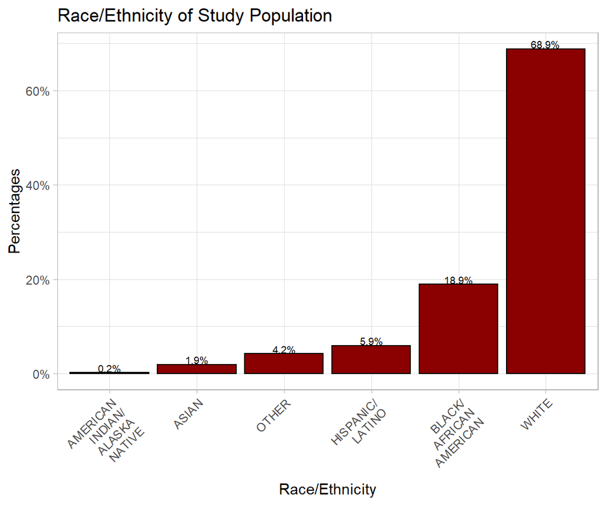

```r
dermptscomplete %>%
  filter((ethnicity %in% race)) %>%
  dplyr::count(ethnicity = factor(ethnicity)) %>%
  mutate(pct = (prop.table(n))) %>%
  ggplot(aes(x = ethnicity,
             y = pct,
             label =  scales::percent(pct))) +
  geom_col(position = "dodge",
           stat = "identity",
           fill = "red4",
           color = "black") +
  geom_text(position = position_dodge(width = 0.9), #move to the center of bars
            vjust = -0.1,
            size = 2.5) +
  scale_y_continuous(labels = scales::percent) +
  scale_x_discrete(limits = c("AMERICAN INDIAN/ALASKA NATIVE", "ASIAN",
                              "OTHER", "HISPANIC/LATINO", "BLACK/AFRICAN AMERICAN", "WHITE"),
                   labels = function(ethnicity) str_wrap(ethnicity, width =
                                                           10)) +
  xlab("Race/Ethnicity") +
  ylab("Percentages") +
  ggtitle("Race/Ethnicity of Study Population") +
  theme_light() +
  theme(axis.text.x = element_text(angle = 45, hjust = 1))
```

#### Admission Type & Insurance

```r
class(dermptscomplete$admission_type)
```

```
## [1] "character"
```

```r
dermptscomplete$admission_type <- as.factor(dermptscomplete$admission_type)
unique(dermptscomplete$admission_type)
```

```
## [1] EW EMER.                    EU OBSERVATION
## [3] DIRECT OBSERVATION          AMBULATORY OBSERVATION
## [5] DIRECT EMER.                ELECTIVE
## [7] URGENT                      SURGICAL SAME DAY ADMISSION
## [9] OBSERVATION ADMIT
## 9 Levels: AMBULATORY OBSERVATION DIRECT EMER. DIRECT OBSERVATION ... URGENT
```

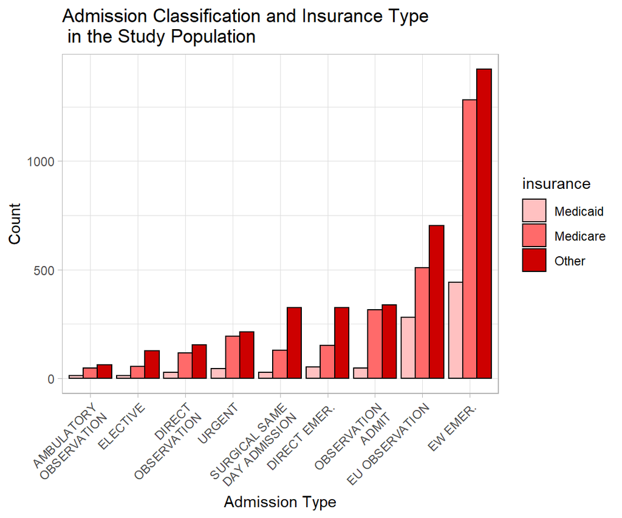

```r
dermptscomplete %>%
  ggplot(aes(admission_type, fill = insurance)) +
  geom_bar(position = position_dodge(), color = "black") +
  scale_x_discrete(limits = c("AMBULATORY OBSERVATION", "ELECTIVE", "DIRECT OBSERVATION", "URGENT", "SURGICAL SAME DAY ADMISSION", "DIRECT EMER.", "OBSERVATION ADMIT", "EU OBSERVATION", "EW EMER."),
    labels = function(admission_type) str_wrap(admission_type, width =
                                                           15)) +
  scale_fill_manual(values = c("rosybrown1", "indianred1", "red3")) +
  xlab("Admission Type") +
  ylab("Count") +
  ggtitle("Admission Classification and Insurance Type \n in the Study Population") +
  theme_light() +
  theme(axis.text.x = element_text(angle = 45, hjust = 1))
```

#### Age Distribution by Gender

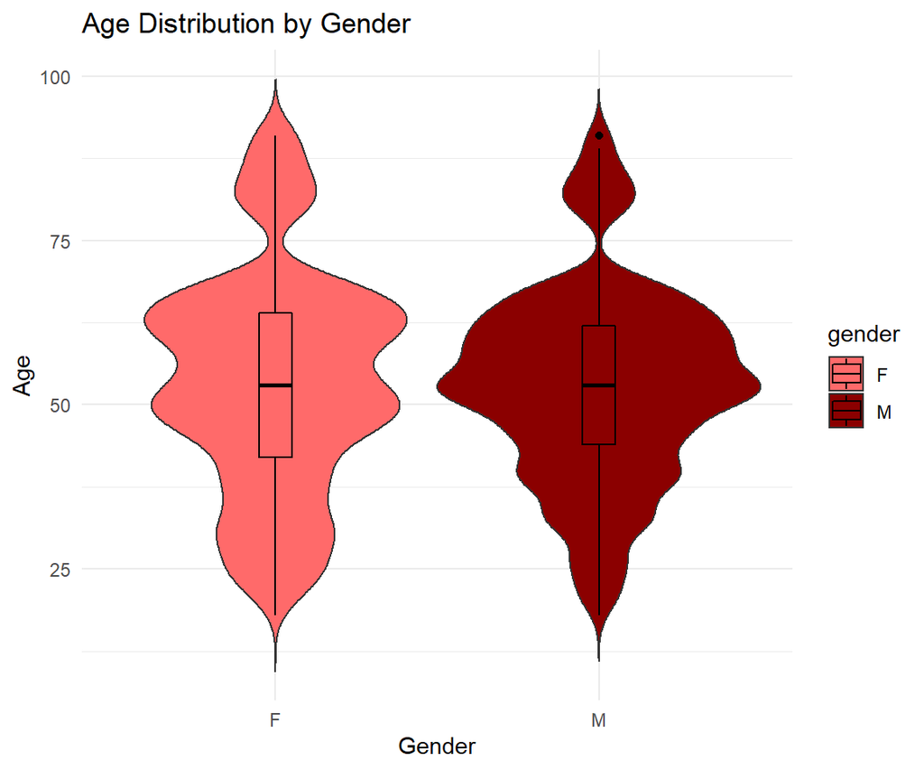

```r
my_colors <- c("indianred1", "red4")

dermptscomplete %>%
  ggplot(aes(gender, anchor_age, fill = gender)) +
  geom_violin(width = 1, trim = FALSE) +
  geom_boxplot(width = 0.1, color = "black", alpha = 0.2) +
  scale_fill_manual(values = my_colors) +
  xlab("Gender") +
  ylab("Age") +
  theme(axis.text.x = element_text(angle = 45, hjust = 1),
        legend.position = "none",
        plot.title = element_text(size = 11)) +
  theme_minimal() +
  ggtitle("Age Distribution by Gender")
```

#### MACE Outcomes by Age and Ethnicity

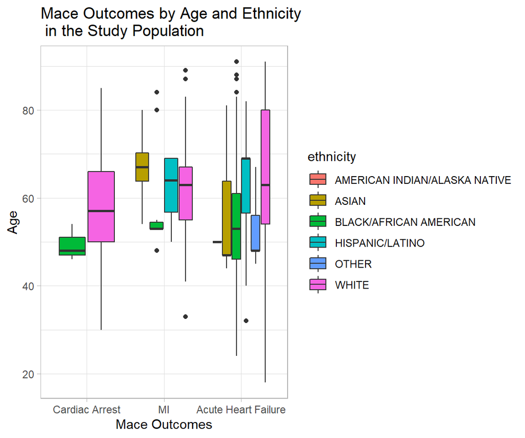

```r
dermptscomplete %>%
  pivot_longer(15:41, names_to = "outcomes", values_to = "presence") %>%
  mutate(outcomes = recode(outcomes, mace_MI = "MI", mace_cardiacarrest = "Cardiac Arrest", mace_ahf = "Acute Heart Failure")) %>%
  filter(outcomes %in% c("MI", "Cardiac Arrest", "Acute Heart Failure"))%>%
  filter(presence == 1) %>%
  filter(ethnicity %in% c("AMERICAN INDIAN/ALASKA NATIVE", "ASIAN", "BLACK/AFRICAN AMERICAN", "HISPANIC/LATINO", "OTHER", "WHITE")) %>%
  ggplot(aes(x = outcomes,
             y = anchor_age)) +
  geom_boxplot(aes(fill = ethnicity), width = 0.75) +
  scale_x_discrete(limits = c("Cardiac Arrest", "MI",
                              "Acute Heart Failure")) +
  xlab("Mace Outcomes") +
  ylab("Age") +
  ggtitle("Mace Outcomes by Age and Ethnicity \n in the Study Population") +
  theme_light()
```

#### MACE Outcomes Count

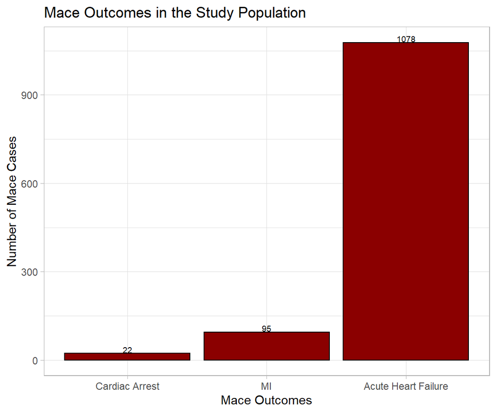

```r
dermptscomplete %>%
  pivot_longer(15:41, names_to = "outcomes", values_to = "presence") %>%
  mutate(outcomes = recode(outcomes, mace_MI = "MI", mace_cardiacarrest = "Cardiac Arrest", mace_ahf = "Acute Heart Failure")) %>%
  filter(outcomes %in% c("MI", "Cardiac Arrest", "Acute Heart Failure"))%>%
  filter(presence == 1) %>%
  group_by(outcomes) %>%
  dplyr::summarize(total = sum(presence)) %>%
  ggplot(aes(x = outcomes,
             y = total,
             label = total)) +
  geom_col(position = "dodge",
           stat = "identity",
           fill = "red4",
           color = "black") +
   geom_text(position = position_dodge(width = 0.9), #move to the center of bars
            vjust = -0.1,
            size = 2.5) +
  scale_x_discrete(limits = c("Cardiac Arrest", "MI",
                              "Acute Heart Failure")) +
  xlab("Mace Outcomes") +
  ylab("Number of Mace Cases") +
  ggtitle("Mace Outcomes in the Study Population") +
  theme_light()
```

#### MACE Type by Gender

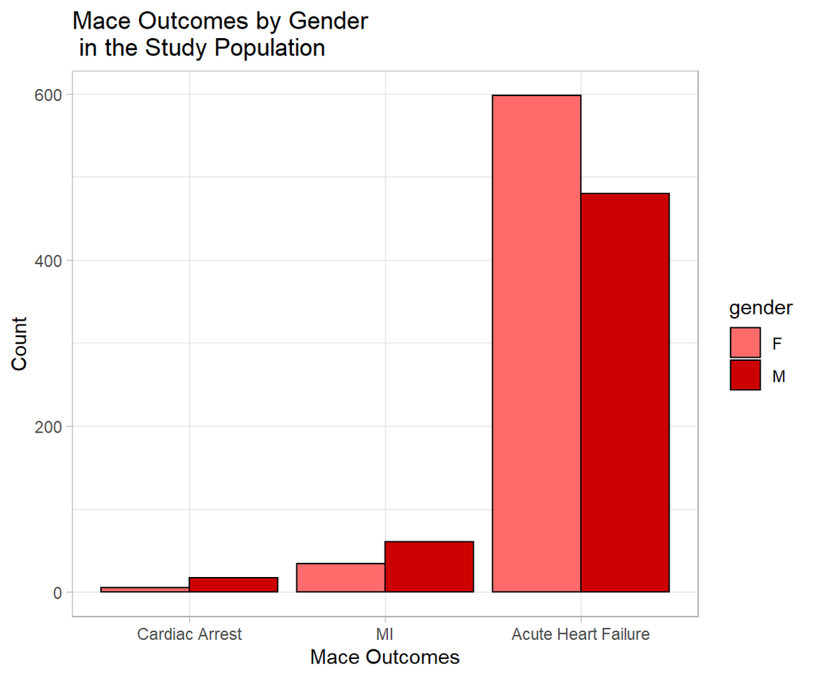

```r
dermptscomplete %>%
  pivot_longer(15:41, names_to = "outcomes", values_to = "presence") %>%
  mutate(outcomes = recode(outcomes, mace_MI = "MI", mace_cardiacarrest = "Cardiac Arrest", mace_ahf = "Acute Heart Failure")) %>%
  filter(outcomes %in% c("MI", "Cardiac Arrest", "Acute Heart Failure"))%>%
  filter(presence == 1) %>%
  group_by(outcomes, gender) %>%
  ggplot(aes(x = outcomes)) +
  geom_bar(aes(fill = gender), position = position_dodge(), color = "black") +
  scale_x_discrete(limits = c("Cardiac Arrest", "MI",
                              "Acute Heart Failure")) +
  scale_fill_manual(values = c("indianred1", "red3")) +
  xlab("Mace Outcomes") +
  ylab("Count") +
  ggtitle("Mace Outcomes by Gender \n in the Study Population") +
  theme_light()
```

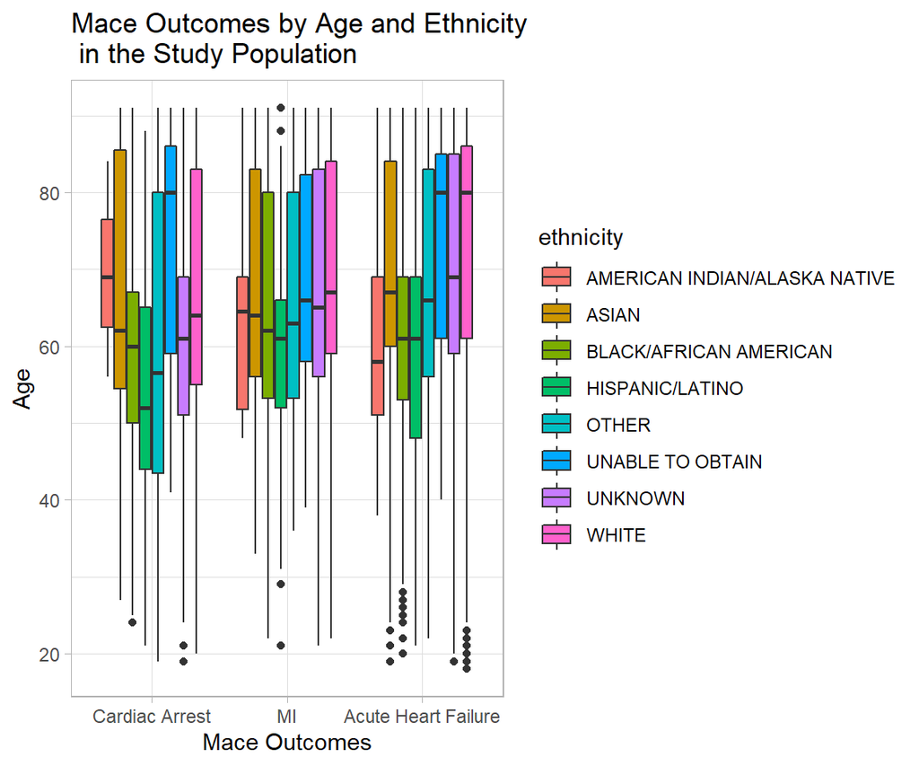

```r
admsubjcomplete %>%
  pivot_longer(15:41, names_to = "outcomes", values_to = "presence") %>%
  mutate(outcomes = recode(outcomes, mace_MI = "MI", mace_cardiacarrest = "Cardiac Arrest", mace_ahf = "Acute Heart Failure")) %>%
  filter(outcomes %in% c("MI", "Cardiac Arrest", "Acute Heart Failure"))%>%
  filter(presence == 1) %>%
  ggplot(aes(x = outcomes,
             y = anchor_age)) +
  geom_boxplot(aes(fill = ethnicity), width = 0.75) +
  scale_x_discrete(limits = c("Cardiac Arrest", "MI",
                              "Acute Heart Failure")) +
  xlab("Mace Outcomes") +
  ylab("Age") +
  ggtitle("Mace Outcomes by Age and Ethnicity \n in the Study Population") +
  theme_light()
```

#### Some initial boxplots of the outcome MACE per admission:

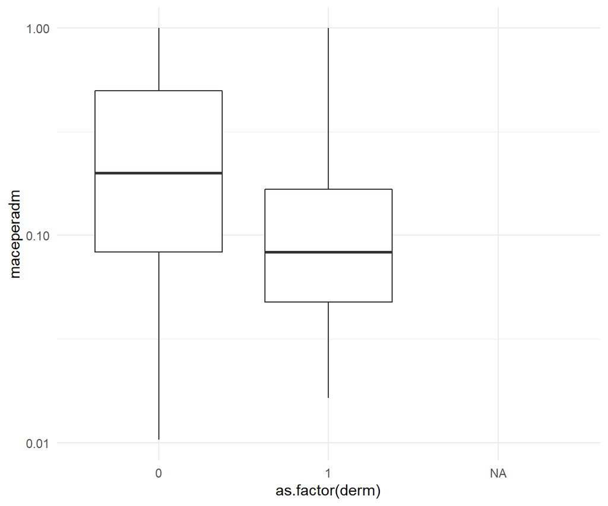

```r
# All patients
admsubjcomplete %>%
  ggplot(aes(as.factor(derm),maceperadm)) +
  geom_boxplot() +
  scale_y_continuous(trans = "log10") +
  theme_minimal()
```

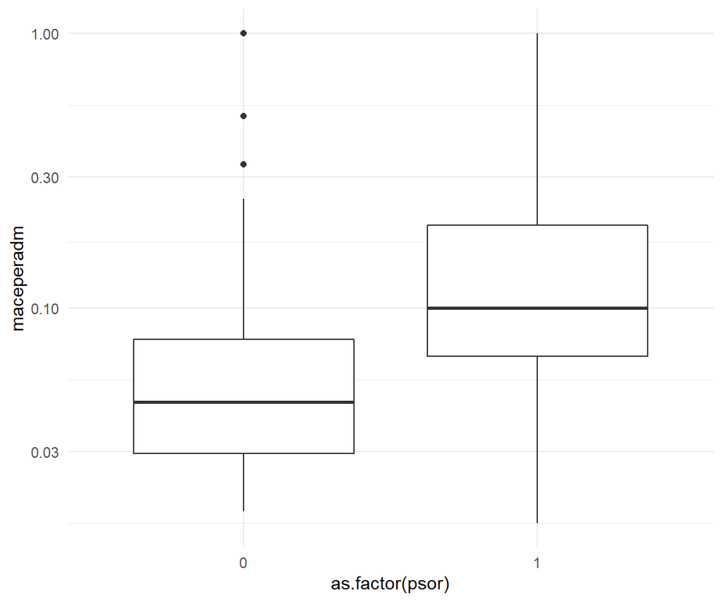

```r
# Derm patients only
dermptscomplete %>%
  ggplot(aes(as.factor(psor),maceperadm)) +
  geom_boxplot() +
  scale_y_continuous(trans = "log10") +
  theme_minimal()
```

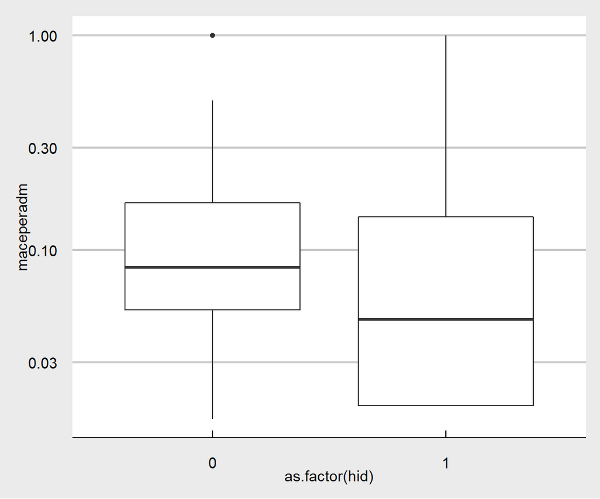

```r
dermptscomplete %>%
  ggplot(aes(as.factor(hid),maceperadm)) +
  geom_boxplot() +
  scale_y_continuous(trans = "log10") +
  theme_economist_white()
```

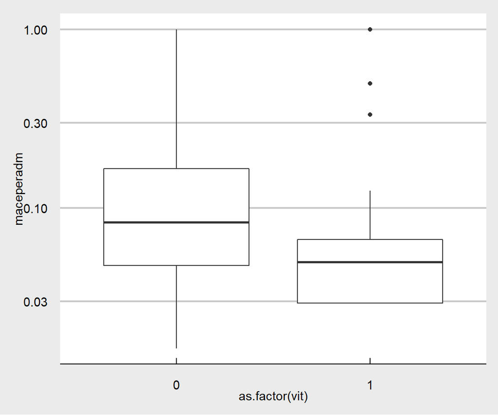

```r
dermptscomplete %>%
  ggplot(aes(as.factor(vit),maceperadm)) +
  geom_boxplot() +
  scale_y_continuous(trans = "log10") +
  theme_economist_white()
```

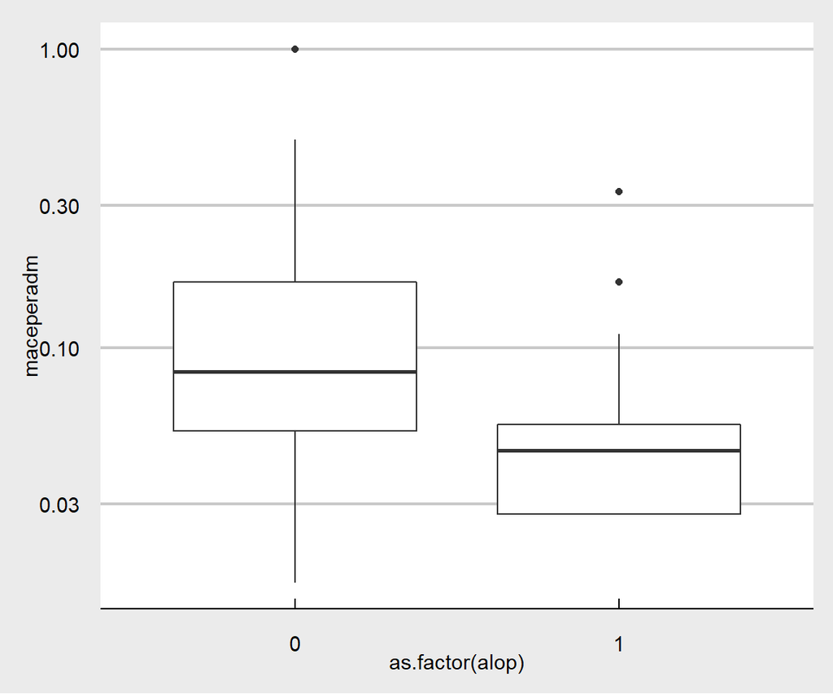

```r
dermptscomplete %>%
  ggplot(aes(as.factor(alop),maceperadm)) +
  geom_boxplot() +
  scale_y_continuous(trans = "log10") +
  theme_economist_white()
```

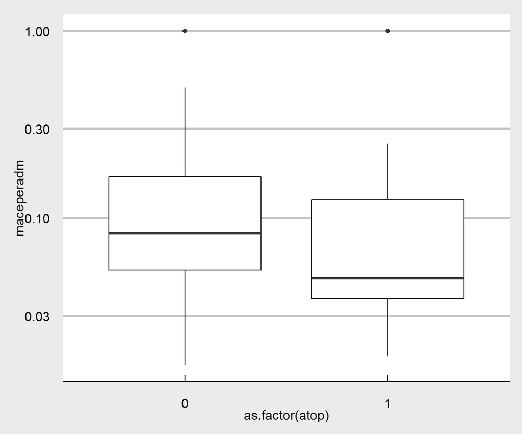

```r
dermptscomplete %>%
  ggplot(aes(as.factor(atop),maceperadm)) +
  geom_boxplot() +
  scale_y_continuous(trans = "log10") +
  theme_economist_white()
```

## Logistic regression models

#### Assessing the impact of CISD conditions on our outcome

First, we will take the whole population and assess for the impact of having dermatologic conditions on the primary outcome

```r
# Treating CISD conditions as a whole:
glmmaceall_derm <- glm(mace ~ age_cat + gender + ethnicity + language + admission_location + insurance + marital_status + derm + mi + chf + hiv + pvd + cva + copd + rheum + malig + miliv + livmodsev + dm, data = admsubjcomplete, family = "binomial")
tab <- cbind(round(exp(summary(glmmaceall_derm)$coefficients[,1]),3),round(exp(confint.default(glmmaceall_derm))[,1],3),round(exp(confint.default(glmmaceall_derm))[,2],3),round((summary(glmmaceall_derm)$coefficients[,4]),5))
colnames(tab) <- c("Odds ratio for MACE","2.5% CI limit","97.5% CI limit","p-value")
kable(tab)
```

|  | Odds ratio for MACE | 2.5% CI limit | 97.5% CI limit | p-value |
| --- | --- | --- | --- | --- |
| (Intercept) | 0.003 | 0.002 | 0.006 | 0.00000 |
| age_cat1 | 2.362 | 2.086 | 2.675 | 0.00000 |
| age_cat2 | 3.901 | 3.481 | 4.372 | 0.00000 |
| age_cat3 | 5.719 | 5.119 | 6.389 | 0.00000 |
| age_cat4 | 8.254 | 7.389 | 9.219 | 0.00000 |
| age_cat5 | 18.671 | 16.682 | 20.898 | 0.00000 |
| age_cat6 | 28.168 | 25.011 | 31.723 | 0.00000 |
| genderM | 1.250 | 1.218 | 1.282 | 0.00000 |
| ethnicityASIAN | 0.760 | 0.568 | 1.015 | 0.06337 |
| ethnicityBLACK/AFRICAN AMERICAN | 1.076 | 0.814 | 1.422 | 0.60691 |
| ethnicityHISPANIC/LATINO | 1.053 | 0.793 | 1.398 | 0.72302 |
| ethnicityOTHER | 1.093 | 0.823 | 1.452 | 0.53865 |
| ethnicityUNABLE TO OBTAIN | 2.031 | 1.454 | 2.836 | 0.00003 |
| ethnicityUNKNOWN | 1.818 | 1.358 | 2.435 | 0.00006 |
| ethnicityWHITE | 0.940 | 0.712 | 1.241 | 0.66411 |
| languageENGLISH | 0.854 | 0.818 | 0.892 | 0.00000 |
| admission_locationCLINIC REFERRAL | 1.441 | 0.758 | 2.741 | 0.26507 |
| admission_locationEMERGENCY ROOM | 2.114 | 1.117 | 4.000 | 0.02137 |
| admission_locationINFORMATION NOT AVAILABLE | 0.799 | 0.341 | 1.875 | 0.60658 |
| admission_locationINTERNAL TRANSFER TO OR FROM PSYCH | 0.537 | 0.265 | 1.092 | 0.08584 |
| admission_locationPACU | 1.157 | 0.604 | 2.215 | 0.66060 |
| admission_locationPHYSICIAN REFERRAL | 1.229 | 0.649 | 2.326 | 0.52668 |
| admission_locationPROCEDURE SITE | 1.917 | 1.008 | 3.646 | 0.04709 |
| admission_locationTRANSFER FROM HOSPITAL | 3.466 | 1.831 | 6.563 | 0.00014 |
| admission_locationTRANSFER FROM SKILLED NURSING FACILITY | 1.925 | 1.010 | 3.668 | 0.04656 |
| admission_locationWALK-IN/SELF REFERRAL | 1.295 | 0.682 | 2.460 | 0.42908 |
| insuranceMedicare | 1.271 | 1.207 | 1.339 | 0.00000 |
| insuranceOther | 1.088 | 1.033 | 1.145 | 0.00130 |
| marital_statusMARRIED | 1.079 | 1.029 | 1.131 | 0.00171 |
| marital_statusSINGLE | 1.066 | 1.015 | 1.119 | 0.01027 |
| marital_statusWIDOWED | 1.251 | 1.185 | 1.321 | 0.00000 |
| derm | 1.204 | 1.115 | 1.300 | 0.00000 |
| mi | 2.070 | 2.010 | 2.131 | 0.00000 |
| chf | 7.465 | 7.262 | 7.672 | 0.00000 |
| hiv | 0.641 | 0.574 | 0.717 | 0.00000 |
| pvd | 0.761 | 0.728 | 0.796 | 0.00000 |
| cva | 0.955 | 0.866 | 1.054 | 0.36182 |
| copd | 3.190 | 3.103 | 3.279 | 0.00000 |
| rheum | 1.060 | 1.005 | 1.118 | 0.03121 |
| malig | 0.870 | 0.792 | 0.956 | 0.00378 |
| miliv | 1.078 | 1.034 | 1.123 | 0.00043 |
| livmodsev | 0.653 | 0.598 | 0.713 | 0.00000 |
| dm | 0.697 | 0.671 | 0.724 | 0.00000 |

Here, we can see that in addition to classical risk factors for MACE (such as age, male sex, prior MI, diagnosed CHF, and COPD), **having a CISD confers a 1.20-times higher odds of having a MACE during hospitalization**, holding the other covariates constant.

```r
# Treating CISD conditions individually:
glmmaceall <- glm(mace ~ age_cat + gender + ethnicity + language + admission_location + insurance + marital_status + hid + vit + psor + atop + alop + mi + chf + hiv + pvd + cva + copd + rheum + malig + miliv + livmodsev + dm, data = admsubjcomplete, family = "binomial")
tab <- cbind(round(exp(summary(glmmaceall)$coefficients[,1]),3),round(exp(confint.default(glmmaceall))[,1],3),round(exp(confint.default(glmmaceall))[,2],3),round((summary(glmmaceall)$coefficients[,4]),5))
colnames(tab) <- c("Odds ratio for MACE","2.5% CI limit","97.5% CI limit","p-value")
kable(tab)
```

|  | Odds ratio for MACE | 2.5% CI limit | 97.5% CI limit | p-value |
| --- | --- | --- | --- | --- |
| (Intercept) | 0.003 | 0.002 | 0.006 | 0.00000 |
| age_cat1 | 2.359 | 2.083 | 2.671 | 0.00000 |
| age_cat2 | 3.899 | 3.479 | 4.370 | 0.00000 |
| age_cat3 | 5.712 | 5.113 | 6.381 | 0.00000 |
| age_cat4 | 8.238 | 7.375 | 9.202 | 0.00000 |
| age_cat5 | 18.638 | 16.651 | 20.861 | 0.00000 |
| age_cat6 | 28.118 | 24.966 | 31.668 | 0.00000 |
| genderM | 1.249 | 1.218 | 1.282 | 0.00000 |
| ethnicityASIAN | 0.761 | 0.569 | 1.018 | 0.06577 |
| ethnicityBLACK/AFRICAN AMERICAN | 1.079 | 0.816 | 1.426 | 0.59396 |
| ethnicityHISPANIC/LATINO | 1.055 | 0.794 | 1.401 | 0.71332 |
| ethnicityOTHER | 1.098 | 0.826 | 1.458 | 0.52025 |
| ethnicityUNABLE TO OBTAIN | 2.035 | 1.457 | 2.843 | 0.00003 |
| ethnicityUNKNOWN | 1.823 | 1.361 | 2.441 | 0.00006 |
| ethnicityWHITE | 0.942 | 0.714 | 1.244 | 0.67567 |
| languageENGLISH | 0.854 | 0.818 | 0.892 | 0.00000 |
| admission_locationCLINIC REFERRAL | 1.441 | 0.757 | 2.741 | 0.26566 |
| admission_locationEMERGENCY ROOM | 2.113 | 1.117 | 3.999 | 0.02149 |
| admission_locationINFORMATION NOT AVAILABLE | 0.799 | 0.341 | 1.875 | 0.60679 |
| admission_locationINTERNAL TRANSFER TO OR FROM PSYCH | 0.537 | 0.264 | 1.091 | 0.08575 |
| admission_locationPACU | 1.157 | 0.604 | 2.216 | 0.66070 |
| admission_locationPHYSICIAN REFERRAL | 1.228 | 0.649 | 2.325 | 0.52745 |
| admission_locationPROCEDURE SITE | 1.916 | 1.008 | 3.645 | 0.04731 |
| admission_locationTRANSFER FROM HOSPITAL | 3.464 | 1.830 | 6.561 | 0.00014 |
| admission_locationTRANSFER FROM SKILLED NURSING FACILITY | 1.924 | 1.009 | 3.666 | 0.04681 |
| admission_locationWALK-IN/SELF REFERRAL | 1.295 | 0.682 | 2.460 | 0.42980 |
| insuranceMedicare | 1.272 | 1.207 | 1.340 | 0.00000 |
| insuranceOther | 1.088 | 1.033 | 1.145 | 0.00131 |
| marital_statusMARRIED | 1.078 | 1.028 | 1.130 | 0.00191 |
| marital_statusSINGLE | 1.065 | 1.014 | 1.118 | 0.01148 |
| marital_statusWIDOWED | 1.249 | 1.183 | 1.319 | 0.00000 |
| hid | 1.003 | 0.757 | 1.329 | 0.98248 |
| vit | 1.110 | 0.833 | 1.480 | 0.47538 |
| psor | 1.212 | 1.105 | 1.329 | 0.00004 |
| atop | 1.331 | 1.027 | 1.725 | 0.03049 |
| alop | 1.270 | 0.972 | 1.658 | 0.07959 |
| mi | 2.070 | 2.010 | 2.131 | 0.00000 |
| chf | 7.465 | 7.263 | 7.673 | 0.00000 |
| hiv | 0.641 | 0.573 | 0.716 | 0.00000 |
| pvd | 0.761 | 0.728 | 0.795 | 0.00000 |
| cva | 0.955 | 0.866 | 1.054 | 0.36326 |
| copd | 3.188 | 3.102 | 3.277 | 0.00000 |
| rheum | 1.060 | 1.005 | 1.118 | 0.03182 |
| malig | 0.871 | 0.793 | 0.957 | 0.00413 |
| miliv | 1.077 | 1.033 | 1.123 | 0.00046 |
| livmodsev | 0.652 | 0.597 | 0.712 | 0.00000 |
| dm | 0.697 | 0.671 | 0.724 | 0.00000 |

Now examining the CISD conditions individually, we see that **psoriasis confers a 1.2-times higher odds of having a MACE during hospitalization, and the other CISD conditions do no have a strong association, and atopic dermatitis confers a 1.3-times higher odds**, holding all other covariates constant. This is an interesting association, and so now we will analyze the CISD population in more detail.

#### Assessing the risk factors for our outcome within the population of patients with CISD

Now, focusing just on patients with CISD, we will again conduct logistic regression for the primary outcome

```r
# Logistic regression for the primary outcome
glmmacederm <- glm(mace ~ age_cat + gender+ ethnicity + language + admission_location + insurance + marital_status + mi + chf + hiv + pvd + cva + copd + rheum + malig + miliv + livmodsev + dm, data = dermptscomplete, family = "binomial")
tab <- cbind(round(exp(summary(glmmacederm)$coefficients[,1]),3),round(exp(confint.default(glmmacederm))[,1],3),round(exp(confint.default(glmmacederm))[,2],3),round((summary(glmmacederm)$coefficients[,4]),5))
colnames(tab) <- c("Odds ratio for MACE","2.5% CI limit","97.5% CI limit","p-value")
kable(tab)
```

|  | Odds ratio for MACE | 2.5% CI limit | 97.5% CI limit | p-value |
| --- | --- | --- | --- | --- |
| (Intercept) | 0.000 | 0.000 | 2.900592e+199 | 0.95193 |
| age_cat1 | 3.604 | 1.522 | 8.537000e+00 | 0.00356 |
| age_cat2 | 4.477 | 1.927 | 1.040300e+01 | 0.00049 |
| age_cat3 | 5.561 | 2.419 | 1.278700e+01 | 0.00005 |
| age_cat4 | 6.073 | 2.628 | 1.403200e+01 | 0.00002 |
| age_cat5 | 12.719 | 5.367 | 3.014100e+01 | 0.00000 |
| age_cat6 | 11.154 | 4.218 | 2.949300e+01 | 0.00000 |
| genderM | 1.271 | 1.068 | 1.513000e+00 | 0.00706 |
| ethnicityASIAN | 0.051 | 0.013 | 2.060000e-01 | 0.00003 |
| ethnicityBLACK/AFRICAN AMERICAN | 0.099 | 0.030 | 3.250000e-01 | 0.00014 |
| ethnicityHISPANIC/LATINO | 0.061 | 0.018 | 2.080000e-01 | 0.00001 |
| ethnicityOTHER | 0.116 | 0.034 | 3.960000e-01 | 0.00058 |
| ethnicityUNABLE TO OBTAIN | 0.012 | 0.001 | 1.400000e-01 | 0.00044 |
| ethnicityUNKNOWN | 0.684 | 0.161 | 2.911000e+00 | 0.60726 |
| ethnicityWHITE | 0.116 | 0.036 | 3.760000e-01 | 0.00032 |
| languageENGLISH | 0.274 | 0.188 | 3.980000e-01 | 0.00000 |
| admission_locationCLINIC REFERRAL | 623980.500 | 0.000 | 3.863877e+211 | 0.95598 |
| admission_locationEMERGENCY ROOM | 801715.707 | 0.000 | 4.963238e+211 | 0.95516 |
| admission_locationINFORMATION NOT AVAILABLE | 678711.487 | 0.000 | 4.230313e+211 | 0.95571 |
| admission_locationINTERNAL TRANSFER TO OR FROM PSYCH | 178861.676 | 0.000 | 1.112078e+211 | 0.96010 |
| admission_locationPACU | 390462.831 | 0.000 | 2.418713e+211 | 0.95753 |
| admission_locationPHYSICIAN REFERRAL | 478468.820 | 0.000 | 2.962166e+211 | 0.95686 |
| admission_locationPROCEDURE SITE | 534545.493 | 0.000 | 3.310066e+211 | 0.95649 |
| admission_locationTRANSFER FROM HOSPITAL | 1281117.470 | 0.000 | 7.931806e+211 | 0.95361 |
| admission_locationTRANSFER FROM SKILLED NURSING FACILITY | 531186.123 | 0.000 | 3.290157e+211 | 0.95652 |
| admission_locationWALK-IN/SELF REFERRAL | 579543.803 | 0.000 | 3.588582e+211 | 0.95623 |
| insuranceMedicare | 1.075 | 0.813 | 1.422000e+00 | 0.61228 |
| insuranceOther | 0.814 | 0.612 | 1.083000e+00 | 0.15819 |
| marital_statusMARRIED | 0.866 | 0.655 | 1.144000e+00 | 0.31150 |
| marital_statusSINGLE | 0.703 | 0.536 | 9.220000e-01 | 0.01083 |
| marital_statusWIDOWED | 0.719 | 0.505 | 1.024000e+00 | 0.06770 |
| mi | 1.848 | 1.527 | 2.236000e+00 | 0.00000 |
| chf | 6.846 | 5.745 | 8.157000e+00 | 0.00000 |
| hiv | 0.417 | 0.220 | 7.920000e-01 | 0.00752 |
| pvd | 0.692 | 0.534 | 8.980000e-01 | 0.00554 |
| cva | 0.307 | 0.140 | 6.730000e-01 | 0.00319 |
| copd | 4.432 | 3.762 | 5.221000e+00 | 0.00000 |
| rheum | 1.432 | 1.096 | 1.871000e+00 | 0.00858 |
| malig | 0.967 | 0.662 | 1.414000e+00 | 0.86393 |
| miliv | 0.885 | 0.716 | 1.095000e+00 | 0.26041 |
| livmodsev | 0.920 | 0.555 | 1.526000e+00 | 0.74700 |
| dm | 0.751 | 0.595 | 9.470000e-01 | 0.01571 |

Now, specifically analyzing the patients with CISD, we see that beyond the non-modifiable risk factors such as age, ethnicity, and male sex, **the risk factors for MACE are prior MI (OR of 1.85), CHF (OR 6.85), COPD (OR 4.43), and interestingly, rheumatologic conditions (OR 1.43)**, when holding the other covariates constant (including admission origin, marital status, Medicare insurance, etc.). Protective factors include prior stroke, peripheral vascular disease, diabetes, and HIV.

This has important implications for which CISD patients should be targeted for more aggressive monitoring when admitted to the hospital.

## Multinomial regression models

#### Assessing the predictive risk factors among all patients for the components of the MACE outcome

We will seek to establish which MACE components (acute HF, acute MI, cardiac arrest) are at risk in patients with CISD.

```r
mnmod_all <- multinom(macemulti ~ derm + age_cat + gender+ ethnicity + language + admission_location + insurance + marital_status + mi + chf + hiv + pvd + cva + copd + rheum + malig + miliv + livmodsev + dm, data = admsubjcomplete)
summ.MNfit(mnmod_all)
```

```
##
## Level 1 vs. Level 0
##                                                          betaHat    se  pval
## (Intercept)                                               -8.461 1.538 0.000
## derm                                                       0.186 0.099 0.061
## age_cat1                                                   0.541 0.144 0.000
## age_cat2                                                   1.104 0.127 0.000
## age_cat3                                                   1.499 0.122 0.000
## age_cat4                                                   1.777 0.122 0.000
## age_cat5                                                   2.237 0.125 0.000
## age_cat6                                                   2.350 0.134 0.000
## genderM                                                    0.381 0.032 0.000
## ethnicityASIAN                                             0.001 0.406 0.999
## ethnicityBLACK/AFRICAN AMERICAN                           -0.174 0.397 0.661
## ethnicityHISPANIC/LATINO                                  -0.041 0.401 0.918
## ethnicityOTHER                                             0.499 0.399 0.211
## ethnicityUNABLE TO OBTAIN                                  1.697 0.413 0.000
## ethnicityUNKNOWN                                           1.549 0.399 0.000
## ethnicityWHITE                                             0.164 0.394 0.678
## languageENGLISH                                           -0.282 0.050 0.000
## admission_locationCLINIC REFERRAL                          0.478 1.489 0.748
## admission_locationEMERGENCY ROOM                           1.909 1.479 0.197
## admission_locationINFORMATION NOT AVAILABLE               -1.060 2.731 0.698
## admission_locationINTERNAL TRANSFER TO OR FROM PSYCH       0.375 1.537 0.807
## admission_locationPACU                                     1.248 1.487 0.401
## admission_locationPHYSICIAN REFERRAL                       0.508 1.480 0.732
## admission_locationPROCEDURE SITE                           2.093 1.481 0.158
## admission_locationTRANSFER FROM HOSPITAL                   2.943 1.479 0.047
## admission_locationTRANSFER FROM SKILLED NURSING FACILITY   1.534 1.487 0.302
## admission_locationWALK-IN/SELF REFERRAL                   -1.160 1.521 0.446
## insuranceMedicare                                          0.251 0.069 0.000
## insuranceOther                                             0.386 0.067 0.000
## marital_statusMARRIED                                      0.110 0.057 0.054
## marital_statusSINGLE                                      -0.018 0.060 0.770
## marital_statusWIDOWED                                      0.182 0.068 0.007
## mi                                                         1.816 0.032 0.000
## chf                                                        0.442 0.039 0.000
## hiv                                                       -0.534 0.153 0.000
## pvd                                                       -0.351 0.062 0.000
## cva                                                       -0.054 0.110 0.624
```

[output cut: 347 more lines]

```
## insuranceOther                                               1.128
## marital_statusMARRIED                                        1.813
## marital_statusSINGLE                                         2.090
## marital_statusWIDOWED                                        3.327
## mi                                                           1.098
## chf                                                          1.757
## hiv                                                          1.643
## pvd                                                          1.433
## cva                                                          2.186
## copd                                                         1.634
## rheum                                                        1.776
## malig                                                        2.616
## miliv                                                        2.062
## livmodsev                                                    1.350
## dm                                                           0.720
```

Here again, we see that in patients with CISD:

1. The **risk of developing an MI (Level 1 vs 0 of the multinomial model) could be said to be associated with our CISD conditions, with a relative risk ratio (RRR) of 1.20**, but using an $\alpha$ threshold of 0.05, this would not be *strictly* significant with a *p*-value of 0.06.
2. The **risk of developing an acute heart failure (Level 2 vs 0 of the multinomial model) is, however, associated with the CISD conditions (Relative risk ratio [RRR] 1.20),** with a *p*-value less than 0.001.
3. **It is notable, however, that having a CISD condition appears protective against having a cardiac arrest (Level 3 vs 0 of the multinomial model), with a RRR of 0.39,** *p* = 0.014.

Now will again zero in on the population of hospitalized CISD patients to assess risk factors for particular subcomponents of the MACE outcome using multinomial regression.

#### Assessing the predictive risk factors among CISD patients for the components of the MACE outcome

```r
mnmod <- multinom(macemulti ~ age_cat + gender+ ethnicity + language + admission_location + insurance + marital_status + mi + chf + hiv + pvd + cva + copd + rheum + malig + miliv + livmodsev + dm, data = dermptscomplete)
summ.MNfit(mnmod)
```

```
##
## Level 1 vs. Level 0
##                                                          betaHat     se  pval
## (Intercept)                                              -26.793 12.219 0.028
## age_cat1                                                   9.170  3.416 0.007
## age_cat2                                                   9.250  3.400 0.007
## age_cat3                                                  10.424  3.383 0.002
## age_cat4                                                  10.637  3.382 0.002
## age_cat5                                                  11.249  3.390 0.001
## age_cat6                                                  -2.166  0.116 0.000
## genderM                                                    0.467  0.273 0.087
## ethnicityASIAN                                             7.028 18.137 0.698
## ethnicityBLACK/AFRICAN AMERICAN                            6.042 18.133 0.739
## ethnicityHISPANIC/LATINO                                   4.782 18.138 0.792
## ethnicityOTHER                                            -4.497 90.430 0.960
## ethnicityUNABLE TO OBTAIN                                -12.414  0.002 0.000
## ethnicityUNKNOWN                                           8.801 18.142 0.628
## ethnicityWHITE                                             6.355 18.132 0.726
## languageENGLISH                                           -2.116  0.467 0.000
## admission_locationCLINIC REFERRAL                         -5.814  0.271 0.000
## admission_locationEMERGENCY ROOM                           6.995  2.562 0.006
## admission_locationINFORMATION NOT AVAILABLE               -3.387  0.007 0.000
## admission_locationINTERNAL TRANSFER TO OR FROM PSYCH      -8.913  0.001 0.000
## admission_locationPACU                                     6.552  2.705 0.015
## admission_locationPHYSICIAN REFERRAL                       5.585  2.581 0.030
## admission_locationPROCEDURE SITE                           6.236  2.633 0.018
## admission_locationTRANSFER FROM HOSPITAL                   8.079  2.571 0.002
## admission_locationTRANSFER FROM SKILLED NURSING FACILITY   6.300  2.707 0.020
## admission_locationWALK-IN/SELF REFERRAL                   -6.622  0.101 0.000
## insuranceMedicare                                         -0.247  0.450 0.582
## insuranceOther                                             0.018  0.430 0.967
## marital_statusMARRIED                                      0.028  0.473 0.953
## marital_statusSINGLE                                       0.198  0.475 0.677
## marital_statusWIDOWED                                     -1.262  0.722 0.080
## mi                                                         2.186  0.245 0.000
## chf                                                        1.141  0.273 0.000
## hiv                                                       -1.536  1.097 0.162
## pvd                                                       -0.802  0.384 0.037
## cva                                                      -10.733  0.001 0.000
## copd                                                       0.671  0.241 0.005
```

[output cut: 381 more lines]

```
## insuranceOther                                            1.168000e+00
## marital_statusMARRIED                                     1.064900e+01
## marital_statusSINGLE                                      6.822000e+00
## marital_statusWIDOWED                                     0.000000e+00
## mi                                                        1.100300e+01
## chf                                                       5.869000e+00
## hiv                                                       9.209000e+00
## pvd                                                       1.720400e+01
## cva                                                       6.672370e+65
## copd                                                      4.817000e+00
## rheum                                                     0.000000e+00
## malig                                                     2.242400e+01
## miliv                                                     2.965000e+00
## livmodsev                                                 2.310843e+33
## dm                                                        0.000000e+00
```

Here again, we see that in patients with CISD:

1. The **risk of developing an MI (Level 1 vs 0 of the multinomial model) is associated with the *modifiable* risk factors of prior MI (Relative risk ratio [RRR] 8.93), CHF diagnosis (RRR 3.13), and COPD (RRR 1.96)**, using a *p*-value threshold of 0.05,.
2. The **risk of developing an acute heart failure (Level 2 vs 0 of the multinomial model) is associated with the *modifiable* risk factors of prior MI (Relative risk ratio [RRR] 1.51), CHF diagnosis (RRR 7.64), and COPD (RRR 4.95). Rheumatologic disorder is again a risk factor with a RRR of 1.41.** For this outcome subcomponent, peripheral vascular disease, stroke HIV, and diabetes are again protective
3. The risk of sufffering cardiac arrest (Level 3 vs 0 of the multinomial model) is **not strongly predicted by any of the modifiable risk factors, but however is associated with the strong protective factors of diabetes and rheumatologic disorders.**

Taken together, the findings from our regression models indicate that **patients with CISD should be targeted for aggresive monitoring, particularly patients with psoriasis or atopic dermatitis**. Moreover, not only we should have particular suspicion in patients with CISD who have the standard risk factors such as MI, CHF, and COPD (especially for acute MI and acute heart failure), but **we should also raise our suspicion if concomitant rheumatologic disease is present**.

We will investigate this further with use of machine learning models to more precisely predict the risk of MACE in patients with CISD.

## Developing machine learning models for prediction of MACE events particularly among hospitalized patients with Chronic Inflammatory Skin Diseases (CISD)

### Random Forest, k Nearest Neighbors (knn) with k=4, knn with k=8, knn with k=12

In a subgroup of patients with chronic inflammatory skin diseases (CISD), including psoriasis, hidradenitis suppuritiva/ acne inversa, atopic dermatitis, alopecia areata, and vitiligo, we aimed at identifying the best prediction model of in-hospital major adverse cardiac events (MACE) out of the following machine learning models: k-nearest neighbor (kNN) with k=4, k=8 and k=12, linear discriminant analysis (LDA), and random forest analysis. The predictor variables are the covariates of the primary model which were selected based on clinical reasoning.

#### Data Wrangling

```r
# Load Data
load("dermptscomplete.RData")

# Select and reformat variables
data <- dermptscomplete %>% dplyr::select(subject_id,mace, gender, age_cat, ethnicity, mi, chf, hiv, pvd, cva, copd, rheum,  livmodsev, malig, miliv, pleg, dm, numadm) %>%
  mutate(gender = as.factor(gender),
                        age_cat = as.factor(age_cat),
                        ethnicity = as.factor(ethnicity),
                        mi = as.factor(mi),
                        chf = as.factor(chf),
                        hiv = as.factor(hiv),
                        pvd = as.factor(pvd),
                        cva = as.factor(cva),
                        copd = as.factor(copd),
                        rheum = as.factor(rheum),
                        livmodsev = as.factor(livmodsev),
                        malig = as.factor(malig),
                        miliv = as.factor(miliv),
                        pleg = as.factor(pleg),
                        dm = as.factor(dm),
                        numadm = as.numeric(numadm),
                        mace = as.factor(mace))

# Use complete cases
data <- data[complete.cases(data), ]
```

#### Create Training and Test Set

```r
set.seed(1)

x <- stratified(data, "mace", 0.7, keep.rownames = TRUE)
train_set <- x %>% dplyr::select(-rn)
train_index <- as.numeric(x$rn)
test_set <- data[-train_index,]

dim(train_set)
```

```
## [1] 5178   18
```

The training set had 5178 rows and 18 columns.

#### KNN Models

##### KNN with k=4

```r
knn_fit <- knn3(mace~.,data = dplyr::select(train_set, mace, gender, age_cat, ethnicity, mi, chf, hiv, pvd, cva, copd, rheum, livmodsev, malig, miliv, pleg, dm, numadm), k = 4)
f_hat_4 <- predict(knn_fit, newdata = test_set)[,2]
tab_4 <- table(pred=round(f_hat_4), truth=test_set$mace)
confusionMatrix(tab_4, positive = "1")
```

```
## Confusion Matrix and Statistics
##
##     truth
## pred    0    1
##    0 1791  190
##    1   86  152
##
##                Accuracy : 0.8756
##                  95% CI : (0.8612, 0.8891)
##     No Information Rate : 0.8459
##     P-Value [Acc > NIR] : 3.840e-05
##
##                   Kappa : 0.4552
##
##  Mcnemar's Test P-Value : 5.651e-10
##
##             Sensitivity : 0.4444
##             Specificity : 0.9542
##          Pos Pred Value : 0.6387
##          Neg Pred Value : 0.9041
##              Prevalence : 0.1541
##          Detection Rate : 0.0685
##    Detection Prevalence : 0.1073
##       Balanced Accuracy : 0.6993
##
##        'Positive' Class : 1
##
```

##### KNN with k=8

```r
knn_fit <- knn3(mace~.,data = dplyr::select(train_set, mace, gender, age_cat, ethnicity, mi, chf, hiv, pvd, cva, copd, rheum, livmodsev, malig, miliv, pleg, dm, numadm), k = 8)
f_hat_8 <- predict(knn_fit, newdata = test_set)[,2]
tab_8 <- table(pred=round(f_hat_8), truth=test_set$mace)
confusionMatrix(tab_8, positive = "1")
```

```
## Confusion Matrix and Statistics
##
##     truth
## pred    0    1
##    0 1806  223
##    1   71  119
##
##                Accuracy : 0.8675
##                  95% CI : (0.8527, 0.8813)
##     No Information Rate : 0.8459
##     P-Value [Acc > NIR] : 0.00224
##
##                   Kappa : 0.379
##
##  Mcnemar's Test P-Value : < 2e-16
##
##             Sensitivity : 0.34795
##             Specificity : 0.96217
##          Pos Pred Value : 0.62632
##          Neg Pred Value : 0.89009
##              Prevalence : 0.15412
##          Detection Rate : 0.05363
##    Detection Prevalence : 0.08562
##       Balanced Accuracy : 0.65506
##
##        'Positive' Class : 1
##
```

##### KNN with k=12

```r
knn_fit <- knn3(mace~.,data = dplyr::select(train_set, mace, gender, age_cat, ethnicity, mi, chf, hiv, pvd, cva, copd, rheum, livmodsev, malig, miliv, pleg, dm, numadm), k =12)
f_hat_12 <- predict(knn_fit, newdata = test_set)[,2]
tab_12 <- table(pred=round(f_hat_12), truth=test_set$mace)
confusionMatrix(tab_12, positive = "1")
```

```
## Confusion Matrix and Statistics
##
##     truth
## pred    0    1
##    0 1819  243
##    1   58   99
##
##                Accuracy : 0.8644
##                  95% CI : (0.8494, 0.8783)
##     No Information Rate : 0.8459
##     P-Value [Acc > NIR] : 0.007872
##
##                   Kappa : 0.332
##
##  Mcnemar's Test P-Value : < 2.2e-16
##
##             Sensitivity : 0.28947
##             Specificity : 0.96910
##          Pos Pred Value : 0.63057
##          Neg Pred Value : 0.88215
##              Prevalence : 0.15412
##          Detection Rate : 0.04461
##    Detection Prevalence : 0.07075
##       Balanced Accuracy : 0.62929
##
##        'Positive' Class : 1
##
```

The accuracy of predicting in-hospital MACE is 0.87 (95% CI, 0.86, 0.88), which is the overall proportion that is predicted correctly. This can be considered good.

#### lda

```r
set.seed(1)

lda_fit <- lda(mace ~ gender + age_cat + ethnicity + mi + chf + hiv + pvd + cva + copd + rheum + livmodsev + malig + miliv + pleg + dm + numadm, data = train_set)

p_hat_lda <- predict(lda_fit, newdata = test_set)$posterior[,2]

y_hat_lda <- factor(ifelse(p_hat_lda > 0.5, 1, 0))

confusionMatrix(data = as.factor(y_hat_lda), reference = test_set$mace, positive = "1")
```

```
## Confusion Matrix and Statistics
##
##           Reference
## Prediction    0    1
##          0 1727  190
##          1  150  152
##
##                Accuracy : 0.8468
##                  95% CI : (0.8311, 0.8615)
##     No Information Rate : 0.8459
##     P-Value [Acc > NIR] : 0.46754
##
##                   Kappa : 0.3828
##
##  Mcnemar's Test P-Value : 0.03442
##
##             Sensitivity : 0.4444
##             Specificity : 0.9201
##          Pos Pred Value : 0.5033
##          Neg Pred Value : 0.9009
##              Prevalence : 0.1541
##          Detection Rate : 0.0685
##    Detection Prevalence : 0.1361
##       Balanced Accuracy : 0.6823
##
##        'Positive' Class : 1
##
```

#### Random Forrest

```r
RNGkind(sample.kind = "Rounding")
set.seed(1)

forest_fit <- randomForest(mace ~ gender + age_cat + ethnicity + mi + chf + hiv + pvd + cva + copd + rheum + livmodsev + malig + miliv + pleg + dm + numadm, data = train_set)

p_hat_forest <- predict(forest_fit, newdata = test_set, type = "prob")[, 2]

y_hat_forest <- factor(ifelse(p_hat_forest > 0.5, 1, 0))

confusionMatrix(data = as.factor(y_hat_forest), reference = test_set$mace, positive = "1")
```

```
## Confusion Matrix and Statistics
##
##           Reference
## Prediction    0    1
##          0 1798  179
##          1   79  163
##
##                Accuracy : 0.8837
##                  95% CI : (0.8697, 0.8968)
##     No Information Rate : 0.8459
##     P-Value [Acc > NIR] : 1.825e-07
##
##                   Kappa : 0.4935
##
##  Mcnemar's Test P-Value : 7.117e-10
##
##             Sensitivity : 0.47661
##             Specificity : 0.95791
##          Pos Pred Value : 0.67355
##          Neg Pred Value : 0.90946
##              Prevalence : 0.15412
##          Detection Rate : 0.07346
##    Detection Prevalence : 0.10906
##       Balanced Accuracy : 0.71726
##
##        'Positive' Class : 1
##
```

The accuracy of predicting in-hospital MACE is 0.88 (95% CI, 0.87, 0.90), which is the overall proportion that is predicted correctly. This can be considered good.

#### ROC Curves

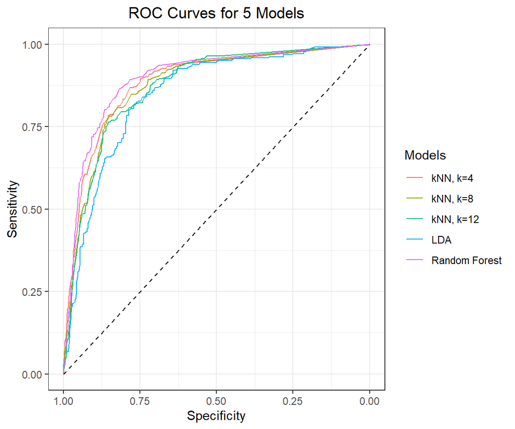

```r
knn_4_roc <- roc(test_set$mace, f_hat_4)
knn_8_roc <- roc(test_set$mace, f_hat_8)
knn_12_roc <- roc(test_set$mace, f_hat_12)
roc_lda <- roc(test_set$mace, p_hat_lda)
roc_forest <- roc(test_set$mace, p_hat_forest)

ggroc(list("kNN, k=4" = knn_4_roc, "kNN, k=8" = knn_8_roc, "kNN, k=12" = knn_12_roc, "LDA" = roc_lda, "Random Forest" = roc_forest), legacy.axes = F)+
  geom_segment(aes(x = 1, xend = 0, y = 0, yend = 1), color = "black", linetype = "dashed") +
  ylab("Sensitivity") +
  xlab("Specificity") +
  labs(color = "Models") +
  ggtitle("ROC Curves for 5 Models") +
  theme_bw() +
  theme(plot.title = element_text(hjust = 0.5))
```

#### AUCs

```r
auc(knn_4_roc)
```

```
## Area under the curve: 0.8856
```

```r
auc(knn_8_roc)
```

```
## Area under the curve: 0.8751
```

```r
auc(knn_12_roc)
```

```
## Area under the curve: 0.8713
```

```r
auc(roc_lda)
```

```
## Area under the curve: 0.8478
```

```r
auc(roc_forest)
```

```
## Area under the curve: 0.8963
```

For the prediction of in-hospital MACE in patients with CISD, the best model in terms of overall accuracy and the receiver operating characteristic curve (AUROC) was the Random Forest (accuracy = 0.88 and AUC=0.89) compared to kNN with various k, and LDA. The AUC can be seen as a “trade-off” measure between sensitivity and the false positive rate (1-specificity). Hence, the Random Forest appears to be overall the best compromise between a relatively high sensitivity and at the same time a relatively small false positive rate, compared to the other to models. In conclusion, the Random Forest performed the best.

#### Gini Index for the covariates/features of the best model

```r
variable_importance <- importance(forest_fit)

tmp <- tibble(feature = rownames(variable_importance),
              Gini = variable_importance[, 1]) %>%
              arrange(desc(Gini))

kable(tmp[1:10, ])
```

| feature | Gini |
| --- | --- |
| chf | 131.28543 |
| copd | 120.07628 |
| numadm | 112.90697 |
| age_cat | 86.17672 |
| mi | 44.88398 |
| ethnicity | 41.05029 |
| gender | 20.24271 |
| miliv | 15.09651 |
| pvd | 15.07891 |
| rheum | 13.94628 |

The top 3 most predictive features of in-hospital MACE were congestive heart failure, number of admissions prior to index admission, and chronic obstructive pulmonary disease (COPD). These results show that CISD patients with these specific comorbidities merit more intensive monitoring while hospitalized.